# Using Sensors to Assess Exercise Form

# Development of a Random Forest Classifier for Predicting the Classe Variable

The training set was used to train random forest models with the caret package. The “cv” method was used for reampling cross-validation and a relatively small number of resamples were used (n = 5) to reduce training time, otherwise the default caret parameters were used. The training was then repeated with each possible combination of sensor locations to determine the minimal number of sensor locations needed to maximize performance. Out-of-sample performance with the cross-validation data set was used to compare the performance for each of the models.

(See Code Chunk “Random Forrest Training” in the Appendix for the code used to train the models)

# Results

The accuracy of each of the models is provided in Table 1. Figure 2 plots the in-sample and out-of-sample accuracy for each model as function of the number of sensor locations in the model. The plot and table show an improvement in accuracy with increasing number of sensors, although the difference between the 3 and 4 sensor models was fairly small and there were some comparable two sensor models. The four sensor location model gave the best out-of-sample accuracy (95%CI) = 0.986 (0.984, 0.989). The number of sensors could be reduced to two locations (belt+forearm), however, with only a minor loss of accuracy. This two sensor location model had an accuracy - 0.976 (0.973, 0.979). The plot also shows that the in-sample and out-of-sample accuracy were similar, indicating that the models did not appear to significantly over-fit the training data.

The confusion matrix for the best performing (four sensor location) model is provided in Table 2.

| Model# | #OfSensors | SensorNames | InSampleAccuracy | OutSampleAccuracy (95%CI) |
| --- | --- | --- | --- | --- |
| **1** | **1** | **belt** | **0.89** | **0.893 (0.887, 0.899)** |
| 2 | 1 | forearm | 0.853 | 0.867 (0.86, 0.873) |
| 3 | 1 | arm | 0.81 | 0.842 (0.836, 0.849) |
| 4 | 1 | dumbbell | 0.862 | 0.87 (0.864, 0.876) |
| **5** | **2** | **belt+forearm** | **0.968** | **0.976 (0.973, 0.979)** |
| 6 | 2 | belt+arm | 0.951 | 0.968 (0.965, 0.971) |
| 7 | 2 | belt+dumbbell | 0.952 | 0.958 (0.954, 0.961) |
| 8 | 2 | forearm+arm | 0.927 | 0.951 (0.947, 0.955) |
| 9 | 2 | forearm+dumbbell | 0.937 | 0.949 (0.945, 0.953) |
| 10 | 2 | arm+dumbbell | 0.946 | 0.955 (0.952, 0.959) |
| 11 | 3 | belt+forearm+arm | 0.974 | 0.981 (0.979, 0.984) |
| **12** | **3** | **belt+forearm+dumbbell** | **0.979** | **0.985 (0.982, 0.987)** |
| 13 | 3 | belt+arm+dumbbell | 0.972 | 0.981 (0.978, 0.983) |
| 14 | 3 | forearm+arm+dumbbell | 0.961 | 0.972 (0.969, 0.975) |
| **15** | **4** | **belt+forearm+arm+dumbbell** | **0.982** | **0.986 (0.984, 0.989)** |

**Table 1.** In sample (training set) and out of sample (x-validation set) accuracy for random forest models used to categorize weight lifting form. The models employed each possible combination of motion sensor locations (belt, arm, forearm and dumbbell). For each model, the table provides the number of location sensors, the actual sensor locations used, the in sample accuracy and the out of sample accuracy (and 95% confidence limit). The best combination of sensor locations for a give number of sensor locations are highlighted in bold.

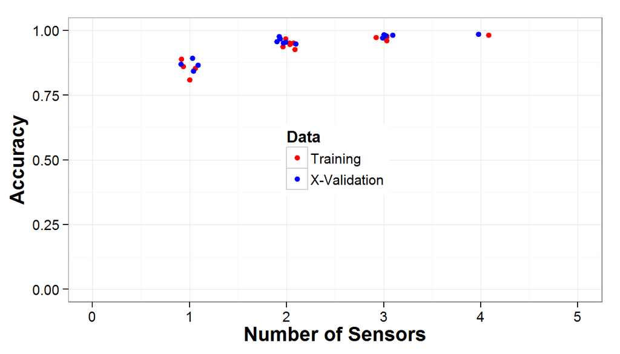

**Figure 2.** The plot shows the prediction accuracy - in sample (training data) and out of sample (x-validation data) - for each of the models listed in Table 1 as a function of the number of sensor locations used. The points are slightly jittered in the x direction to make it easier to see overlapping points.

|  | True A | True B | True C | True D | True E |
| --- | --- | --- | --- | --- | --- |
| **Predicted A** | 3332 | 18 | 0 | 0 | 0 |
| **Predicted B** | 11 | 2232 | 25 | 4 | 5 |
| **Predicted C** | 4 | 19 | 2025 | 29 | 17 |
| **Predicted D** | 1 | 9 | 3 | 1894 | 12 |
| **Predicted E** | 0 | 0 | 0 | 2 | 2130 |
| **Sensitivity** | **0.9952** | **0.9798** | **0.9864** | **0.9819** | **0.9843** |
| **Specificity** | **0.9979** | **0.9953** | **0.9929** | **0.9975** | **0.9998** |

**Table 2.** Confusion matrix for the best random forest model (the model employing all four sensor locations: model #15 in Table 1). The model was applied to the cross-validation data and the number of observations was broken down by predicted category vs. true category for lifting form. The table also shows the sensitivity and specificity for identifying each of the 5 categories.

(See Code Chunk “Results” in the Appendix for the code used to generate Figure 2 and Tables 1 and 2)

# Prediction of Lifting Form for Blinded Test Data Set

| TestObservation | PredictedClasse |
| --- | --- |
| 1 | B |
| 2 | A |
| 3 | B |
| 4 | A |
| 5 | A |
| 6 | E |
| 7 | D |
| 8 | B |
| 9 | A |
| 10 | A |
| 11 | B |
| 12 | C |
| 13 | B |
| 14 | A |
| 15 | E |
| 16 | E |
| 17 | A |
| 18 | B |
| 19 | B |
| 20 | B |

# Conclusion

A random forest model using the data from motion sensors at four location (belt, arm, forearm and dumbbell) on an individual lifting a dumbbell was shown to be highly accurate at classifying the lift form as correct or as one of four different incorrect lift forms - accuracy (95% CI) = 0.986 (0.984, 0.989). A model using only sensors at two locations (belt+forearm) was only slightly worse and had an accuracy (95%) = 0.976 (0.973, 0.979).

# Appendix - R Code

## Data Preparation

```r
# Load required libraries
library(ggplot2)
library(reshape2)
library(plyr)
library(caret)
library(randomForest)
library(pander)

# Load data set
dataset <- read.csv("pml-training.csv")

# Create lists of the different sensor types, locations and axis
sensorTypes <- c("gyros", "accel", "magnet")
calcTypes <- c("roll", "pitch", "yaw", "total_accel")
locations <- c("belt", "forearm", "arm", "dumbbell")
axis <- c("x", "y", "z")

# Create function that generates the full set of field names from the types, locations and axis
# Also will be used to create set of field names if not all locations are used
createFields <- function(sensorTypes = NULL, calcTypes = NULL, locations, axis) {

  if (!is.null(sensorTypes)){
    # Create all combinations of sensorTypes, locations and axis
    temp <- merge(merge(data.frame(sensorTypes), data.frame(locations)),
                  data.frame(axis))
    sensorFields <- as.character(paste(temp[,1], temp[,2], temp[,3], sep = "_"))
  } else {
    sensorFields <- NULL
  }
  if (!is.null(calcTypes)) {
    # Create all combinations of calcType and locations
    temp <- merge(data.frame(calcTypes), data.frame(locations))
    calcFields <- as.character(paste(temp[,1], temp[,2], sep = "_"))
  } else {
    calcFields <- NULL
  }
  # Return the full set of all combinations created above
  c(calcFields, sensorFields)
}

# Generate full set of field names to subset data on, then get rid of unused data columns
fieldNames <- createFields(sensorTypes, calcTypes, locations, axis)
dataset <- dataset[, c("classe", fieldNames)]

# Prove their are no NAs; if so, the following equation should evaluate to 0
number_of_NAs <- sum(sapply(names(dataset), function(x) sum(is.na(dataset[, x]))))

# Create training and x-validation data sets
set.seed(1000)
inTrain <- createDataPartition(dataset$classe, p = 0.4, list = FALSE)[,1]
train <- dataset[inTrain, ]
xval <- dataset[-inTrain, ]
```

## Data Exploration

```r
# To make the dataset easier to work with using ggplot plotting
# The multiple data fields are "melted" into a single long column with name "Value"
# A separate column "Measurement" holds the name of the original field associated with each value
trainMelt <- melt(train, id.vars=1, measure.vars=2:53,
                  variable.name="Measurement", value.name="Value")

# To allow the different features to be plotted on the same scales, the data for each feature is standardized
trainMelt <- ddply(trainMelt, ~ Measurement, mutate,
                   StandValue = (Value - mean(Value)) / sd(Value))

# ggplot is used to generate a facet plot with density plots for each feature
# Within each facet, the density plots are colored by classe
# To make the plots cleaner, I eliminated a outliers further than 4 sd from mean
plot1 <- ggplot(data=trainMelt[trainMelt$StandValue < 4 & trainMelt$StandValue > -4, ])
plot1 <- plot1 + geom_density(aes(StandValue, colour = classe))
plot1 <- plot1 + facet_wrap(~ Measurement, nrow = 11, ncol = 5)
plot1 <- plot1 + scale_x_continuous("Standardized Value", limits = c(-4,4))
plot1 <- plot1 + scale_color_manual(values=c("red", "gray", "gray",
                                             "gray", "gray", "gray"))
plot1 <- plot1 + theme_bw()

remove(trainMelt)
#plot1
```

## Random Forest Training

```r
# Generate a list with vectors with all the possible combinations of sensor locations
# For example each sensor location (e.g., arm) by itself, each possible sets of 2, 3 or 4 locations
combos <- lapply(1:4, function(x) combn(locations, x, simplify = FALSE))
combos <- unlist(combos, recursive=FALSE)

# Create variables to hold results
bestModel = NULL # will hold the model (the combination of sensor locations) with the best accuracy
bestAccuracy = 0 # will hold the accuracy of the best model
bestConfMatrix = NULL # will hold the out-sample confusion matrix for best model
# The results data frame will hold model statistics for each model that is tested
results <- data.frame(Index = 1:length(combos), # The model number
                      Locations = sapply(combos, function(x) paste(x, collapse = "+")), # the sensor locations in the model
                      NumOfSensorSites = sapply(combos, function(x) length(x)), # the number of sensor locations in the model
                      InSampleAccuracy = rep(0.0, length(combos)), # the in-sample accuracy
                      InSampleAccSD = rep(0.0, length(combos)), # the sd for the in-sample accuracy
                      OutSampleAccuracy = rep(0.0, length(combos)), # the out of sample accuracy
                      OutSampleAccLCI = rep(0.0, length(combos)), # the lower 95% CI for the out of sample accuracy
                      OutSampleAccUCI = rep(0.0, length(combos))) # the upper 95% CI for the out of sample accuracy

# Generate and test random forest model for each possible combination of sensor sites
for (i in 1:length(combos)) {

  # Generate the data fields to use in the analysis (for the given subset of sensor locations)
  fields <- createFields(sensorTypes = sensorTypes,
                         calcTypes = calcTypes,
                         locations =  combos[[i]],
                         axis = axis)
  # Create model using 5-fold cross-validation to optimize the mtry parameter
  trCntrl <- trainControl(method = "cv", number = 5)
  model <- train(classe ~ ., data = train[ , c("classe", fields)],
                 method = "rf", prox = TRUE, trControl = trCntrl)

  # Save in-sample results (accuracy mean and standard deviation) in results dataframe
  results$InSampleAccuracy[i] <- mean(model$resample$Accuracy)
  results$InSampleAccSD[i] <- sd(model$resample$Accuracy)

  # Get out-sample results (accuracy estimate and lower/upp confidence limits)
  # Save the accuracy and confidence limits in results dataframe
  predictions <- predict(model, xval[ , fields])
  confMatrix <- confusionMatrix(predictions, xval$classe)
  outAccuracy <- confMatrix$overall[[1]]
  results$OutSampleAccuracy[i] <- outAccuracy
  results$OutSampleAccLCI[i] <- confMatrix$overall[[3]]
  results$OutSampleAccUCI[i] <- confMatrix$overall[[4]]

  # If the current model is the best model so far, update best model variables
  if (outAccuracy > bestAccuracy) {
    bestAccuracy <- outAccuracy
    bestConfMatrix <- confMatrix
    bestModel <- model
  }

}
```

## Results

```r
# Make a nice printable table of the results dataframe
Model <- results$Index
N_Sensors = results$NumOfSensorSites
Sensors = results$Locations
InSampleAccuracy = as.character(round(results$InSampleAccuracy, 3))
OutSampleAccuracy_CI = paste(as.character(signif(results$OutSampleAccuracy, 3)),
                             " (", as.character(signif(results$OutSampleAccLCI, 3)), ", ",
                             as.character(signif(results$OutSampleAccUCI, 3)),
                             ")", sep = "")
resultsToPrint <- data.frame(Model, N_Sensors, Sensors, InSampleAccuracy,
                             OutSampleAccuracy_CI)
names(resultsToPrint) <- c("Model#", "#OfSensors", "SensorNames",
                           "InSampleAccuracy", "OutSampleAccuracy (95%CI)")

# Note:  will print the table inline with the text
#pandoc.table(resultsToPrint, split.table = 400, style = "simple",
#             emphasize.strong.cells = matrix(c(rep(1,5), rep(5,5), rep(12, 5), rep(15,5),
#                                               rep(seq(1:5), 4)), 20, 2))

# Make a nice printable table of the confusion matrix for the best model
confMatrixToPrint <- bestConfMatrix[[2]]
confMatrixToPrint <- rbind(confMatrixToPrint, Sensitivity =
                           sapply(1:5, function(x) {
                             confMatrixToPrint[x, x]/ sum(confMatrixToPrint[, x])
                           }))
confMatrixToPrint <- rbind(confMatrixToPrint, Specificity =
                             sapply(1:5, function(x) {
                               sum(confMatrixToPrint[-x, -x]) / sum(confMatrixToPrint[, -x])
                             }))
confMatrixToPrint <- signif(confMatrixToPrint, 4)
dimnames(confMatrixToPrint) <- list(Predicted = c("Predicte A","Predicted B","Predicted C", "Predicted D", "Predicted E", "Sensitivity", "Specificity"),
                                    Reference = c("True A", "True B", "True C", "True D", "True E"))

# Note:  will print table inline with the text
#pander(confMatrixToPrint, signif = 4, split.table = 200, style = "simple",
#       emphasize.strong.cells = matrix(c(rep(6, 5), rep(7, 5),
#                                         rep(seq(1:5), 2)), 10, 2))

# Generate a plot of accuracy (insample and outsample) vs. the number of sensor locations for all the models
plot2 <- ggplot(data = melt(results, id.vars = "NumOfSensorSites",
                            measure.vars = c("InSampleAccuracy", "OutSampleAccuracy"),
                            variable.name = "InVsOut",
                            value.name = "Accuracy"))
plot2 <- plot2 + geom_point(aes(x = NumOfSensorSites, y = Accuracy, colour = InVsOut),
                            shape = 19, size = 4, position = position_jitter(width = 0.1, height = 0))
plot2 <- plot2 + scale_colour_manual(name = "Data", labels = c("Training", "X-Validation"), values = c("red", "blue"))
plot2 <- plot2 + scale_x_continuous("Number of Sensors", limits = c(0,5))
plot2 <- plot2 + scale_y_continuous("Accuracy", limits = c(0,1))
plot2 <- plot2 + theme_bw()
plot2 <- plot2 + theme(title = element_text(size = 16, face = "bold"),
                       axis.title.y = element_text(vjust = 1),
                       text = element_text(size = 14),
                       legend.position = c(0.5, 0.5))

# Will print plot inline with text
#plot2
```

## Prediction

```r
# Load data set
testset <- read.csv("pml-testing.csv")

# Subset on required data columns
testset <- testset[, fieldNames]

# Predict classe for each row of testset using the best model
predictions <- predict(bestModel, testset[ , fieldNames])

# Set up dataframe with test observation number and predicted classe (lift form category)
testResults <- data.frame(TestObservation = 1:length(predictions), PredictedClasse = predictions)

# Turn into nice table
# Note will print table inline with text
# pander(testResults)
```